# Final Project Report - Data Mining Spring 2020

J-A-G

3/29/2020

## II. Dataset Introduction and Problem Description

```r
train <- read.csv("train.csv")
dim(train) #check dimension
```

```
## [1] 1460   81
```

### 1. Dataset Description

The dataset is made up of independent variables that may or may not affect the values of properties in Ames, Iowa. Some examples are roofing types, last remodeled date, etc. Our data source is from [Kaggle.com’s *House Prices: Advanced Regression Techniques competition*](https://www.kaggle.com/c/house-prices-advanced-regression-techniques). The data set has 80 independent variables and 1 dependent variable, consisting of 1460 observations in the training dataset (450 kb) and 1459 observations in the test dataset (441 kb) (already split by Kaggle). The dependent variable is the sale price of properties in Ames, Iowa.

### 2. Problem definition

We need to predict the final price of residential homes in Ames, Iowa, based on 80 explanatory variables. This could be very powerful as a result. To potential real estate agencies, they could know where to target, if certain locations in the city turned out to sell for more. On the other hand, homeowners could know what to do to raise their property value (remodel, put a new roof on, etc.) depending on which raises the value of their property the most. Moreover, home seekers/potential buyers can choose the features of the homes that they want to buy to estimate the necessary budget.

### 3. Column description

There are 80 explanatory variables describing (almost) every aspect of residential homes in Ames, Iowa, this project expects us to predict the final price of each home. Here are some explanation and description of a few variables as a sample:

- SalePrice - the property’s sale price in dollars. This is the target variable that we’re trying to predict.
- LotFrontage: Linear feet of street connected to property
- LotArea: Lot size in square feet
- Street: Type of road access
- LotShape: General shape of property
- LandContour: Flatness of the property
- Utilities: Type of utilities available

### 4. Some initial concerns with the dataset

There are a few concerns about data preprocessing. Firstly, we have to consider how to deal with missing data. To handle this issue, we will look into the most reasonable interpretation of NA’s for each of the variables, and make the appropriate changes to clean the data. Then, we will assess the implications of those changes on our model. Secondly, we have to take into account the computational speed of each model. If there is an issue with how long a certain analysis type is taking, then we will have to reduce some variables with other methods and re-run, or we will have to remove that type of analysis. However, the data set is relatively small, so we shouldn’t run into these issues. Thirdly, the model can predict very well but is hard to interpret. We will try to opt for a simpler model if the test errors from the 2 models (complex vs. simple) are not drastically different. Also, we should focus more on the meaning of the features in the selected model.

## III. Data Cleaning

### 1. Missing Data Handling

First, we would like to address the problem of missing values. Since there are variables with hundreds or even more than a thousand of missing values, simple deletion is not a good option as we could significantly shrink the sample size.

```
## Grvl Pave NA's
##   50   41 1369
```

```
##   Ex   Fa   Gd NA's
##    2    2    3 1453
```

```
## GdPrv  GdWo MnPrv  MnWw  NA's
##    59    54   157    11  1179
```

Therefore, we have decided to go with the following strategies. For each categorical variable with missing values, we will add a new level called “Missing” to store all of the NA’s. For each numerical variable with missing values, we will replace the NA’s with the median value of that variable. We chose the median over the mean replacement because median is less affected by outliers and thus, is more stable.

```r
# Creating a new level in categorical variables to store NA values

train[] <- lapply(train, function(x){
  # check if you have a factor first:
  if(!is.factor(x)) return(x)
  # otherwise include NAs into factor levels and change factor levels:
  x <- factor(x, exclude=NULL)
  levels(x)[is.na(levels(x))] <- "Missing"
  return(x)
  })
```

```r
summary(train$Alley)
```

```
##    Grvl    Pave Missing
##      50      41    1369
```

```r
# replacing NA's in numerical variables with the respective column median
for (i in 1:ncol(train)) {
  if(is.numeric(train[,i])) {
  train[,i][is.na(train[,i])] <- median(train[,i], na.rm=TRUE)
  }
}
```

### 2. Variable Distribution Assessment

Next, we would like to evaluate the distribution of each predictor. We would use skewness as the metric to assess normality.

```r
# skewness() function comes from this library
library(e1071)
```

```r
factor_list <- c() # a vector that only contain categorical variables from the train dataset
for (i in 1:ncol(train)) {
  a <- is.factor(train[,i])
  if (a == TRUE) {
    factor_list <- c(factor_list,i)
  }
}
```

The factor_list is used to isolate the numerical predictors from categorical predictors in the training dataset.

The following numerical variables are heavily skewed with the absolute value of skewness larger than 3 (our chosen threshold). These variables are likely to not have a normal distribution.

```
## [1] "LotArea 12.182615015142"
## [1] "BsmtFinSF2 4.2465214142744"
## [1] "LowQualFinSF 8.99283328876521"
## [1] "BsmtHalfBath 4.09497489864402"
## [1] "KitchenAbvGr 4.47917825526294"
## [1] "EnclosedPorch 3.08352575096526"
## [1] "X3SsnPorch 10.2831783953225"
## [1] "ScreenPorch 4.11374730864908"
## [1] "PoolArea 14.7979182927495"
## [1] "MiscVal 24.4265223718963"
```

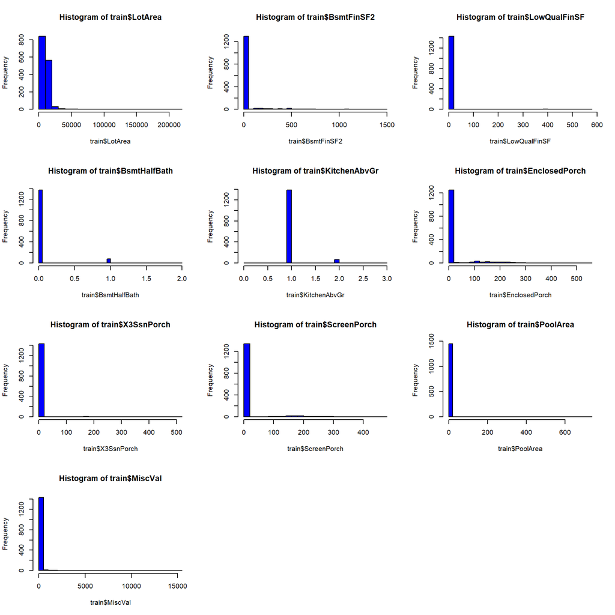

We see that for all of the heavily skewed variables with the exception of LotArea, the major problem is that there are too many zeros (or too many 1’s in the case of KitchenAbvGr). To correct this issue, we will transform those numerical variables into categorical variables with levels of “Zeros” and “More than Zeros” (or “One” and “More than One”).

Let’s check one of the newly transformed variables, MiscVal_new (a modified copy of MiscVal).

```
##           0 More than 0
##        1408          52
```

We will also check the new summary for KitchenAbvGr (a modified copy of KitchenAbvGr).

```
##           0           1 More than 1
##           1        1392          67
```

As we can see, there is one observation that has KitchenAbvGr = 0. This is an outlier,so we decided to remove this observation from our training dataset.

Next, we will alleviate the skewness of LotArea using log-transformation.

Now, our new training dataset will include 1 response variable (SalePrice), 70 original predictors, and 10 transformed variables to replace the problematic ones.

```r
train_off <- train
```

*Analyze response SalePrice

```r
# descriptive statistic summary
summary(train_off$SalePrice)
```

```
##    Min. 1st Qu.  Median    Mean 3rd Qu.    Max.
##   34900  130000  163000  180958  214000  755000
```

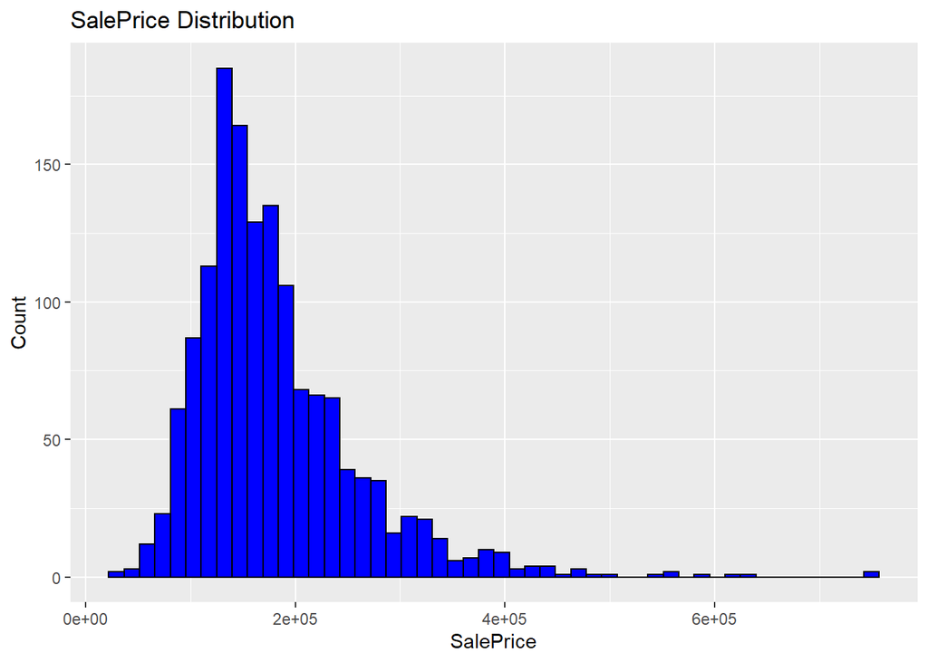

We can see that the distribution is right-skewed. Next, we check Q-Q plot to see if the distribution is close to normal.

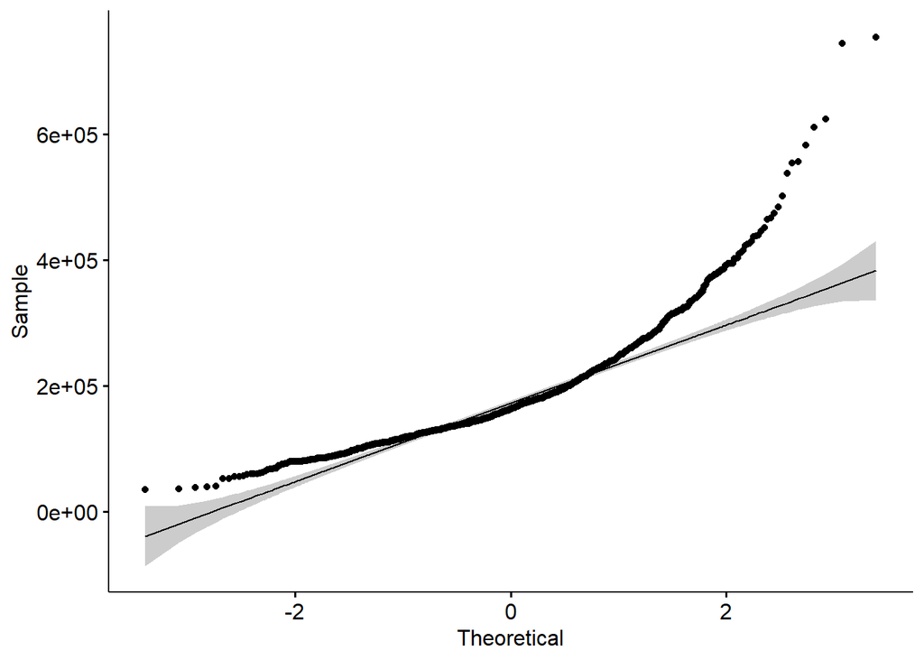

So clearly, the SalePrice distribution is not normal. We will use log-transformation for SalePrice. The picture below tells that the distribution is now much closer to normal.

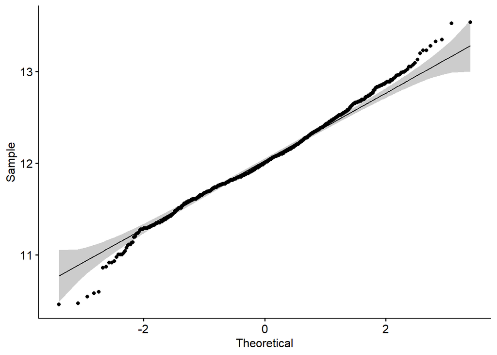

### 3. Dummy variables transformation

Last but not least, we create dummies for all categorical variables in the train_off data frame.

## IV. Data Mining Techniques/Algorithms

### 1. Variable Pre-selection

We will filter out variables to only keep the variables that have a moderately high correlation with response variable y=SalePrice. We have chosen the threshold to be plus/minus 0.4. The resulting subset of variables will be used to fit all of the following models.

```r
# dataset train_X only contain predictors
train_X <- train_off[,-which(colnames(train_off)=="SalePrice")]
num_list <- c() # a vector that only contain numerical variables from the train_off dataset
for (i in 1:ncol(train_X)) {
  a <- is.numeric(train_X[,i])
  if (a == TRUE) {
    num_list <- c(num_list,i)
  }
}

# train_X_num is a dataset that only contains numerical variables
train_X_num <- train_X[,num_list]
dim(train_X_num)
```

```
## [1] 1459  314
```

```r
cors <- cor(train_X_num,train_off$SalePrice)
whichers <- which(abs(cors)>.4)
whichers
```

```
##  [1]   9  88  90  91 142 145 146 154 158 161 175 191 198 211 215 219 224 226 227
## [20] 228 236 242 244 250 251 253 255 256
```

```r
colnames(train_X_num[88])
```

```
## [1] "OverallQual"
```

```r
colnames(train_X_num[191])
```

```
## [1] "TotalBsmtSF"
```

```r
colnames(train_X_num[215])
```

```
## [1] "GrLivArea"
```

```r
colnames(train_X_num[255])
```

```
## [1] "GarageCars"
```

```r
colnames(train_X_num[256])
```

```
## [1] "GarageArea"
```

train_off has 29 variables including 28 predictors and 1 response variable, SalePrice.

```
## [1] 1459   29
```

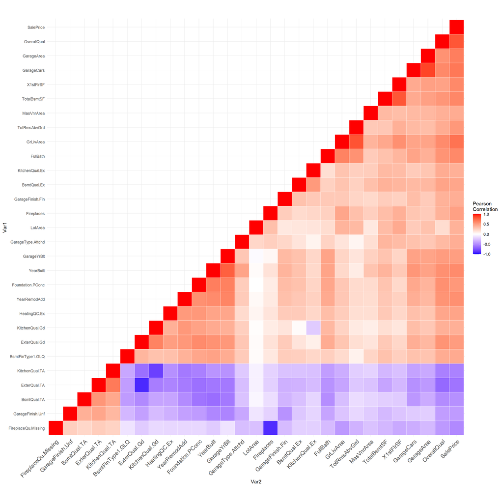

```r
# Fit the variable pre-selection model
var_pre <- lm(SalePrice~., data = train_off)
summary(var_pre) #Adjusted R-squared:  0.8526
```

```
##
## Call:
## lm(formula = SalePrice ~ ., data = train_off)
##
## Residuals:
##      Min       1Q   Median       3Q      Max
## -1.97028 -0.06795  0.01158  0.08592  0.50716
##
## Coefficients:
##                       Estimate Std. Error t value Pr(>|t|)
## (Intercept)          3.954e+00  7.530e-01   5.251 1.74e-07 ***
## LotArea              1.063e-01  9.523e-03  11.159  < 2e-16 ***
## OverallQual          7.856e-02  5.433e-03  14.459  < 2e-16 ***
## YearBuilt            1.808e-03  2.755e-04   6.565 7.28e-11 ***
## YearRemodAdd         2.003e-03  2.969e-04   6.749 2.16e-11 ***
## MasVnrArea           2.260e-05  2.663e-05   0.849 0.396125
## ExterQual.Gd         4.913e-02  2.457e-02   2.000 0.045697 *
## ExterQual.TA         5.801e-02  2.555e-02   2.271 0.023305 *
## Foundation.PConc    -4.707e-04  1.312e-02  -0.036 0.971392
## BsmtQual.Ex          6.275e-02  1.939e-02   3.236 0.001238 **
## BsmtQual.TA          1.609e-02  1.209e-02   1.330 0.183584
## BsmtFinType1.GLQ     5.135e-02  1.090e-02   4.712 2.70e-06 ***
## TotalBsmtSF          7.038e-05  1.812e-05   3.883 0.000108 ***
## HeatingQC.Ex         3.039e-02  1.035e-02   2.935 0.003384 **
## X1stFlrSF           -2.106e-05  2.106e-05  -1.000 0.317405
## GrLivArea            1.686e-04  1.814e-05   9.296  < 2e-16 ***
## FullBath             7.910e-03  1.139e-02   0.694 0.487630
## KitchenQual.Ex       1.471e-01  3.489e-02   4.216 2.64e-05 ***
## KitchenQual.Gd       8.707e-02  2.953e-02   2.948 0.003248 **
## KitchenQual.TA       4.635e-02  2.690e-02   1.723 0.085137 .
## TotRmsAbvGrd         5.463e-03  4.703e-03   1.162 0.245516
## Fireplaces           3.320e-02  1.532e-02   2.167 0.030376 *
## FireplaceQu.Missing -3.260e-02  1.955e-02  -1.668 0.095524 .
## GarageType.Attchd    3.454e-02  1.042e-02   3.315 0.000940 ***
## GarageYrBlt         -7.994e-04  3.123e-04  -2.560 0.010570 *
## GarageFinish.Fin     3.319e-03  1.161e-02   0.286 0.775095
## GarageFinish.Unf    -8.320e-03  1.145e-02  -0.727 0.467451
## GarageCars           5.582e-02  1.291e-02   4.324 1.64e-05 ***
## GarageArea           4.675e-05  4.398e-05   1.063 0.288034
## ---
## Signif. codes:  0 '***' 0.001 '**' 0.01 '*' 0.05 '.' 0.1 ' ' 1
##
## Residual standard error: 0.1534 on 1430 degrees of freedom
## Multiple R-squared:  0.8554, Adjusted R-squared:  0.8526
## F-statistic: 302.2 on 28 and 1430 DF,  p-value: < 2.2e-16
```

We split the train_off to 2 parts that are train_set data set (80% of total observations) and test_set data set (20% of total observations). The test_set will be used to compare the best models across techniques to find the final best-performance model.

```r
set.seed(11)
trainS=sample(1:nrow(train_off),nrow(train_off)*0.8) #create training set # 80/20
train_set <- train_off[trainS,]
test_set <-train_off[-trainS,]
```

### 2. LINEAR REGRESSION TECHNIQUES

### 2.1 BEST SUBSET SELECTION

We will use 10-fold Cross validation to choose the number of variables to include in our best subset selection model.

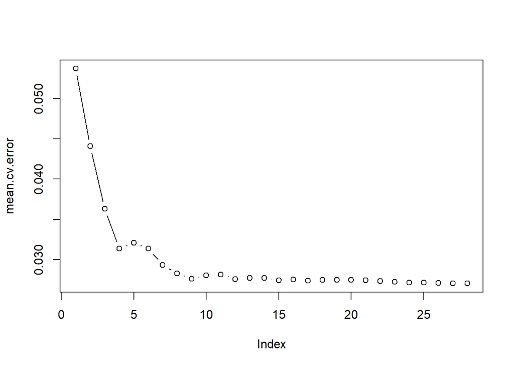

We see that from the point of 9 variables, when we add more variables into the model, the mean cv error does not decrease substantially. Thus, we would use 9 variables in our final best subset selection model. We received a test MSE of 0.01875441. Below are the variables in the final model along with their respective coefficient estimators.

```
## [1] 0.01875441
```

```
##      (Intercept)          LotArea      OverallQual        YearBuilt
##     1.500238e+00     1.070885e-01     9.018400e-02     1.785542e-03
##     YearRemodAdd BsmtFinType1.GLQ      TotalBsmtSF        GrLivArea
##     2.503247e-03     5.221221e-02     6.667633e-05     1.691430e-04
##       Fireplaces       GarageCars
##     6.618327e-02     7.028058e-02
```

### 2.2 LASSO REGRESSION

```
##         (Intercept)             LotArea         OverallQual           YearBuilt
##        3.562722e+00        9.875456e-02        7.935398e-02        1.513384e-03
##        YearRemodAdd          MasVnrArea         BsmtQual.Ex         BsmtQual.TA
##        2.009279e-03        2.332795e-05        4.690704e-02        8.213336e-03
##    BsmtFinType1.GLQ         TotalBsmtSF        HeatingQC.Ex           GrLivArea
##        4.624970e-02        4.771747e-05        3.259321e-02        1.460163e-04
##            FullBath      KitchenQual.Ex      KitchenQual.Gd        TotRmsAbvGrd
##        7.591947e-03        6.760217e-02        3.002766e-02        7.079510e-03
##          Fireplaces FireplaceQu.Missing   GarageType.Attchd         GarageYrBlt
##        4.380824e-02       -2.547013e-02        3.549729e-02       -2.213093e-04
##    GarageFinish.Unf          GarageCars          GarageArea
##       -2.940296e-03        5.851941e-02        3.573118e-05
```

### 2.3 RIDGE REGRESSION

We also try Ridge regression, to see if we get a lower MSE with it over LASSO. We also use 10-fold Cross validation to select the best lambda.

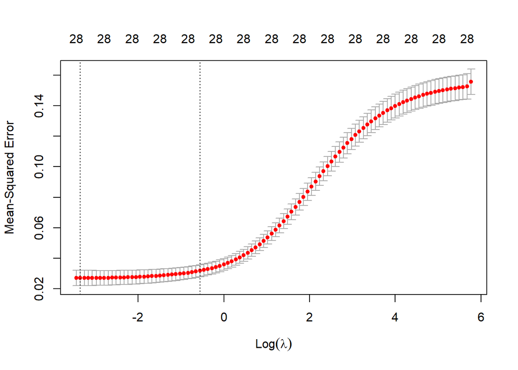

```
## [1] 0.03506961
```

```r
ridge.pred=predict(ridge.mod,s=bestlam_r,newx=x.test) #making prediction using the best shrinkage parameter
ridge_mse = mean((ridge.pred-y.test)^2) #calculate test MSE
ridge_mse
```

```
## [1] 0.01908079
```

### 2.4 Principal Component Regression (PCR)

We decided to include 10 principal components in our final PCR model. The resulting test MSE is 0.02155774.

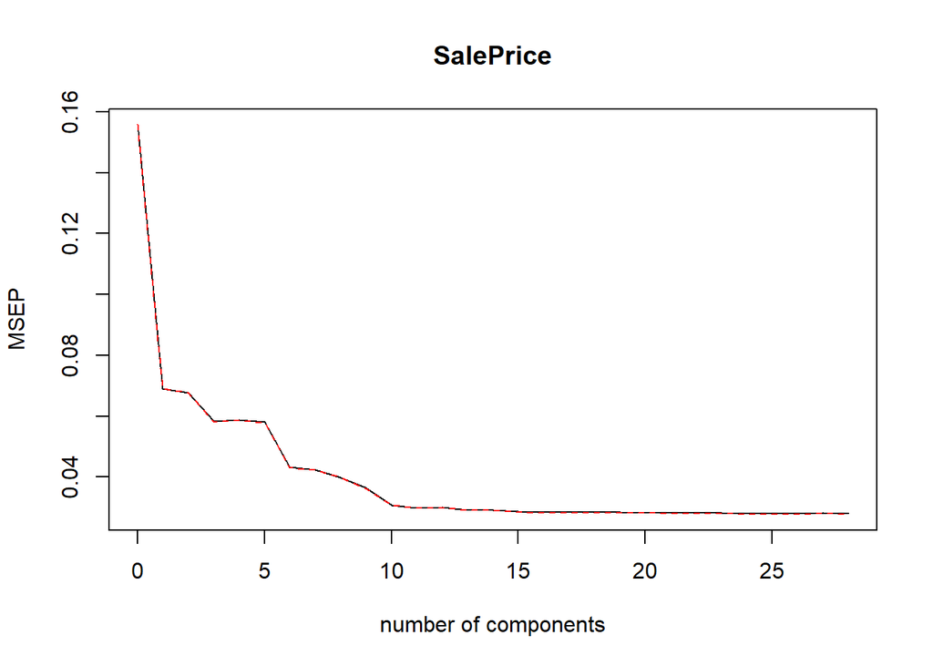

```r
pcr.pred=predict(pcr.fit,test_set,ncomp=10) #make predictions using 10 components
pcr_mse = mean((test_set$SalePrice-pcr.pred)^2) #calculate mse using the test set
pcr_mse
```

```
## [1] 0.02155774
```

### 2.5 PARTIAL LEAST SQUARE REGRESSION (PLS)

Test MSE = 0.02011798 with a 9-component model.

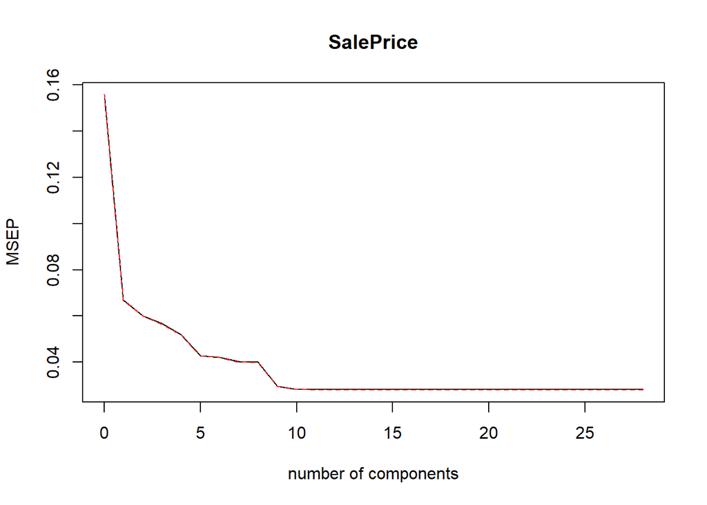

### 3. NON-LINEAR REGRESSION TECHNIQUES

### 3.1 KNN

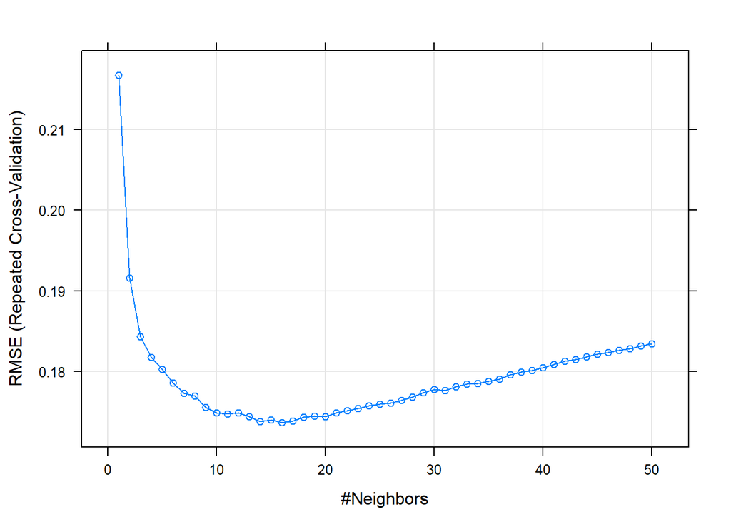

```r
knn.pred=predict(knnFit,test_set,k=16) #make predictions using 9 components

knn_mse = mean((test_set$SalePrice-knn.pred)^2) #calculate mse using the test set
knn_mse
```

```
## [1] 0.02635826
```

### 3.2 Regression Tree

```r
# install.packages("tree")
library(tree)
```

```
##
## Regression tree:
## tree(formula = SalePrice ~ ., data = train_set)
## Variables actually used in tree construction:
## [1] "OverallQual" "GrLivArea"   "TotalBsmtSF" "YearBuilt"   "GarageCars"
## Number of terminal nodes:  10
## Residual mean deviance:  0.04157 = 48.1 / 1157
## Distribution of residuals:
##      Min.   1st Qu.    Median      Mean   3rd Qu.      Max.
## -0.869100 -0.101200  0.009439  0.000000  0.117300  0.715100
```

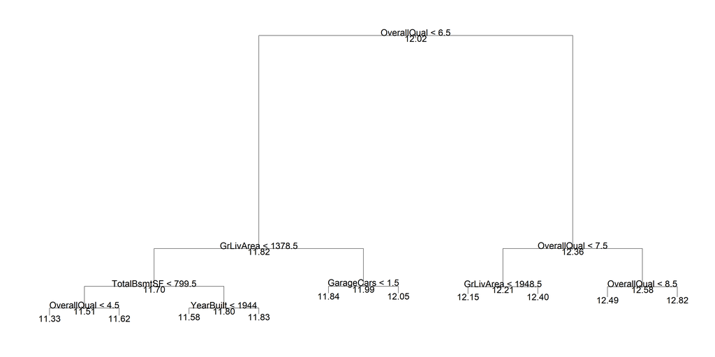

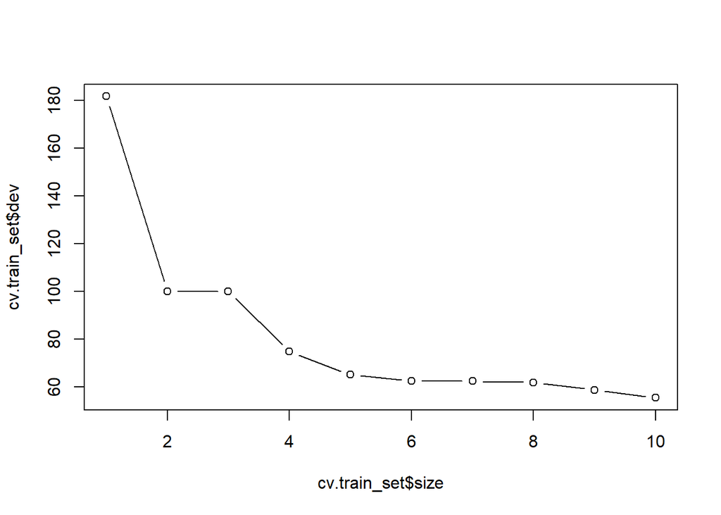

```r
yhat=predict(tree.train_set, newdata=test_set) #make predictions using the best model
price.test= test_set$SalePrice
reg_tree_MSE=mean((yhat-price.test)^2) #calculate test MSE
reg_tree_MSE
```

```
## [1] 0.04432681
```

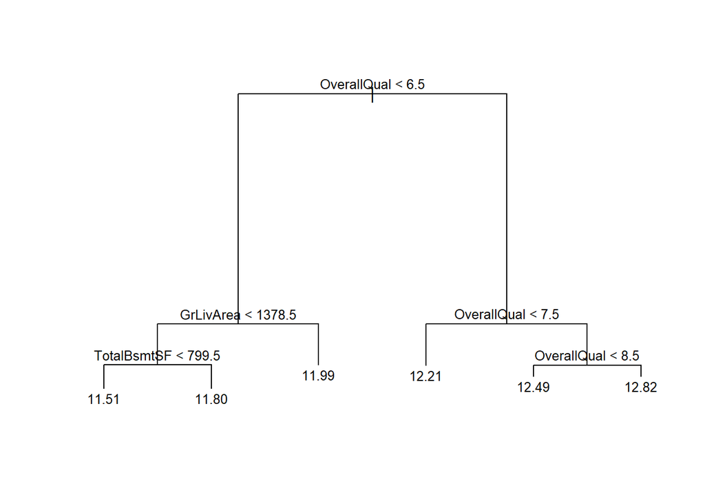

```r
yhat=predict(prune.train_set, newdata=test_set) #make predictions using the tuned model
price.test=test_set$SalePrice
prune_MSE=mean((yhat-price.test)^2) #calculate test MSE
prune_MSE
```

```
## [1] 0.05531215
```

### 3.3 Bagging and Random Forest

```r
set.seed(6)
bag.price=randomForest(SalePrice~.,data=train_set, mtry=28,importance=TRUE) #apply bagging on decision tree
bag.price
```

```
##
## Call:
##  randomForest(formula = SalePrice ~ ., data = train_set, mtry = 28,      importance = TRUE)
##                Type of random forest: regression
##                      Number of trees: 500
## No. of variables tried at each split: 28
##
##           Mean of squared residuals: 0.02546461
##                     % Var explained: 83.63
```

```r
#calculate test error
yhat.bag=predict(bag.price,newdata=test_set)
price.test=test_set$SalePrice
bag_mse = mean((yhat.bag-price.test)^2)
bag_mse
```

```
## [1] 0.01939207
```

```r
set.seed(6)
bag.price=randomForest(SalePrice~.,data=train_set, mtry=28,importance=TRUE,ntree=25) #change the number of trees in bagging
yhat.bag=predict(bag.price,newdata=test_set)
mean((yhat.bag-price.test)^2)
```

```
## [1] 0.02073888
```

```r
set.seed(6)
rf.price=randomForest(SalePrice~.,data=train_set, mtry=20,importance=TRUE,ntree=25) #apply random forest
yhat.rf=predict(rf.price,newdata=test_set)
rf_mse = mean((yhat.rf-price.test)^2)
rf_mse
```

```
## [1] 0.02003089
```

```r
importance(rf.price) #check variable selection based on random forest
```

```
##                        %IncMSE IncNodePurity
## LotArea              3.6239974    5.19586428
## OverallQual          7.4095144   78.23084566
## YearBuilt            4.2204507   17.75956460
## YearRemodAdd         3.9546111    2.99454188
## MasVnrArea           1.0037358    1.38122700
## ExterQual.Gd         2.4485518    0.19833280
## ExterQual.TA         2.4287736    0.65427083
## Foundation.PConc     2.2166914    0.20311054
## BsmtQual.Ex          0.2105302    0.34864912
## BsmtQual.TA          2.6938362    0.44110250
## BsmtFinType1.GLQ     4.9387854    0.57687620
## TotalBsmtSF          7.7334347   12.34613393
## HeatingQC.Ex         3.2068525    0.29644165
## X1stFlrSF            5.4565855    5.43873613
## GrLivArea            8.2142091   27.62630780
## FullBath             2.2461745    0.51742499
## KitchenQual.Ex       2.7058915    0.08957703
## KitchenQual.Gd       3.3203373    0.23383654
## KitchenQual.TA       2.1653131    0.31701291
## TotRmsAbvGrd        -0.4510712    1.18292132
## Fireplaces           1.7066628    3.14963963
## FireplaceQu.Missing  3.1524631    1.90578966
## GarageType.Attchd    2.8054579    0.47261927
## GarageYrBlt          3.0842935    1.97741281
## GarageFinish.Fin     0.5228674    0.14069058
## GarageFinish.Unf     2.2655365    0.39536387
## GarageCars           4.4167806    6.80605547
## GarageArea           5.5777262    6.75864469
```

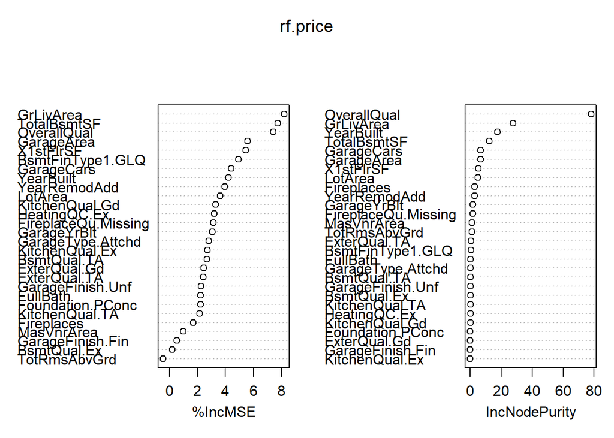

```r
varImpPlot(rf.price)
```

### 3.4 Boosting

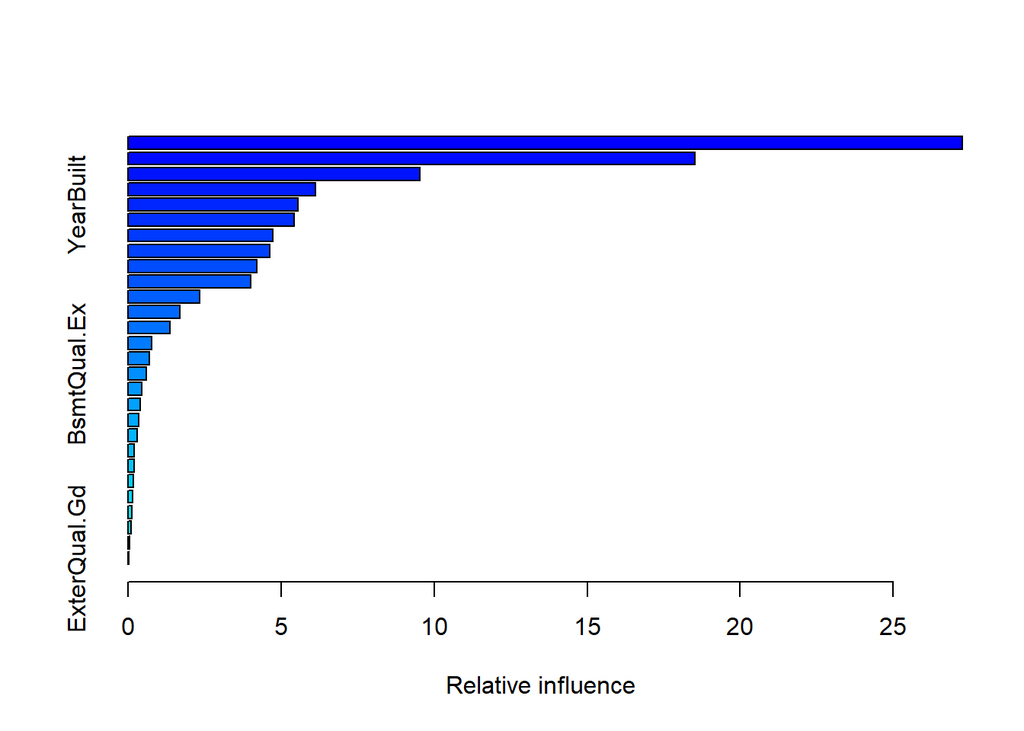

```
##                                     var     rel.inf
## OverallQual                 OverallQual 27.25352633
## GrLivArea                     GrLivArea 18.51529073
## TotalBsmtSF                 TotalBsmtSF  9.53896300
## LotArea                         LotArea  6.11389727
## YearBuilt                     YearBuilt  5.56109721
## GarageArea                   GarageArea  5.42160682
## X1stFlrSF                     X1stFlrSF  4.73668606
## YearRemodAdd               YearRemodAdd  4.62377226
## ExterQual.TA               ExterQual.TA  4.21350675
## GarageCars                   GarageCars  4.01220379
## GarageYrBlt                 GarageYrBlt  2.34302146
## Fireplaces                   Fireplaces  1.68723384
## MasVnrArea                   MasVnrArea  1.36020057
## FireplaceQu.Missing FireplaceQu.Missing  0.78529628
## TotRmsAbvGrd               TotRmsAbvGrd  0.69166981
## BsmtQual.Ex                 BsmtQual.Ex  0.59656157
## GarageType.Attchd     GarageType.Attchd  0.45803355
## BsmtFinType1.GLQ       BsmtFinType1.GLQ  0.41016243
## HeatingQC.Ex               HeatingQC.Ex  0.35304037
## GarageFinish.Unf       GarageFinish.Unf  0.29162618
## BsmtQual.TA                 BsmtQual.TA  0.21287358
## KitchenQual.TA           KitchenQual.TA  0.19370033
## KitchenQual.Gd           KitchenQual.Gd  0.16482709
## FullBath                       FullBath  0.15801157
## KitchenQual.Ex           KitchenQual.Ex  0.12207819
## Foundation.PConc       Foundation.PConc  0.09510235
## GarageFinish.Fin       GarageFinish.Fin  0.05767385
## ExterQual.Gd               ExterQual.Gd  0.02833675
```

```r
set.seed(1)
boost.price=gbm(SalePrice~.,data=train_set,distribution="gaussian",n.tree=1000,interaction.depth = 4) #fit a boosted tree
summary(boost.price)
```

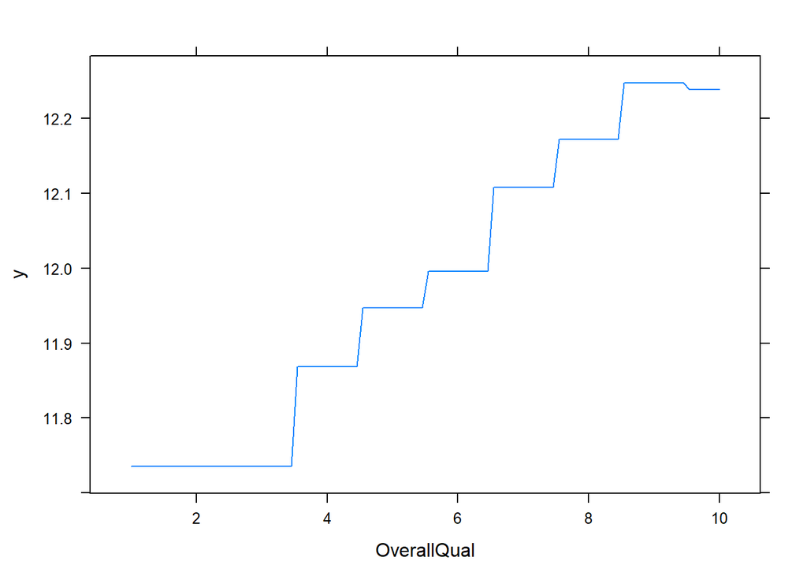

```r
plot(boost.price,i="OverallQual")
```

```r
#calculate test error
yhat.boost=predict(boost.price,newdata=test_set,n.trees=1000)
mean((yhat.boost-price.test)^2)
```

```
## [1] 0.02091361
```

```r
# fit a boosted tree with shrinkage parameter=0.05
# interaction-complexity
# shrinkage-balance
boost.price=gbm(SalePrice~.,data=train_set,distribution="gaussian",n.tree=1000,interaction.depth = 4, shrinkage=0.05)
yhat.boost=predict(boost.price,newdata=test_set,n.trees=1000)
mean((yhat.boost-price.test)^2)
```

```
## [1] 0.01839033
```

```r
print(GBMModel)
```

```
## Stochastic Gradient Boosting
##
## 1167 samples
##   28 predictor
##
## No pre-processing
## Resampling: Cross-Validated (10 fold)
## Summary of sample sizes: 1049, 1051, 1050, 1050, 1050, 1050, ...
## Resampling results across tuning parameters:
##
##   shrinkage  n.minobsinnode  RMSE       Rsquared   MAE
##   0.05       10              0.1537730  0.8508429  0.1037881
##   0.05       15              0.1538543  0.8506796  0.1048401
##   0.10       10              0.1558227  0.8469313  0.1052454
##   0.10       15              0.1541082  0.8513729  0.1049824
##
## Tuning parameter 'n.trees' was held constant at a value of 900
## Tuning
##  parameter 'interaction.depth' was held constant at a value of 2
## RMSE was used to select the optimal model using the smallest value.
## The final values used for the model were n.trees = 900, interaction.depth =
##  2, shrinkage = 0.05 and n.minobsinnode = 10.
```

```r
#The final values used for the model were n.trees = 900, interaction.depth = 2, shrinkage =
#0.05 and n.minobsinnode = 10.
```

```r
# newdata = test set
# 1000<above

yhat.boost=predict(GBMModel,newdata=test_set,n.trees=900)
boost_mse = mean((yhat.boost-price.test)^2)
boost_mse
```

```
## [1] 0.01729698
```

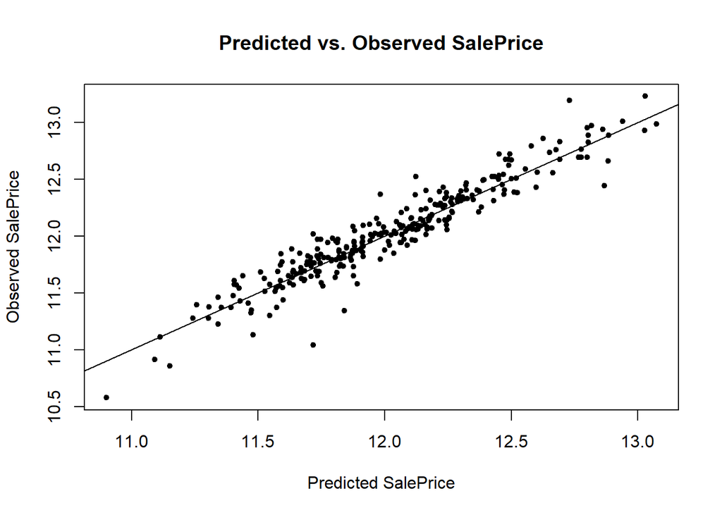

```r
plot(yhat.boost, test_set$SalePrice, pch = 20, xlab = "Predicted SalePrice",
     ylab = "Observed SalePrice", main = "Predicted vs. Observed SalePrice")
abline(0, 1, untf = FALSE)
```

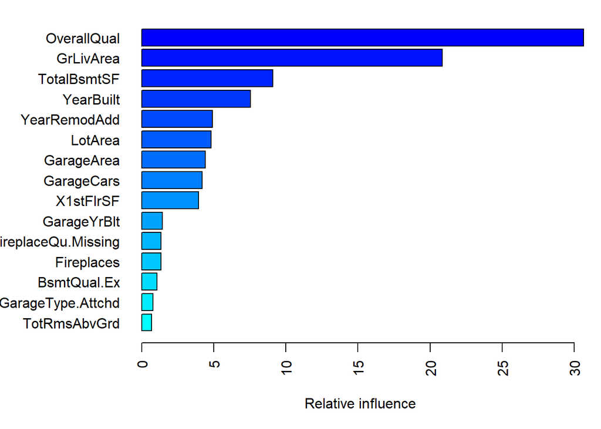

```
##                                     var      rel.inf
## OverallQual                 OverallQual 30.654214124
## GrLivArea                     GrLivArea 20.848899149
## TotalBsmtSF                 TotalBsmtSF  9.099195142
## YearBuilt                     YearBuilt  7.538278765
## YearRemodAdd               YearRemodAdd  4.912021044
## LotArea                         LotArea  4.814969056
## GarageArea                   GarageArea  4.405797978
## GarageCars                   GarageCars  4.211829250
## X1stFlrSF                     X1stFlrSF  3.961856079
## GarageYrBlt                 GarageYrBlt  1.439427573
## FireplaceQu.Missing FireplaceQu.Missing  1.352289810
## Fireplaces                   Fireplaces  1.343226141
## BsmtQual.Ex                 BsmtQual.Ex  1.059043630
## GarageType.Attchd     GarageType.Attchd  0.783840674
## TotRmsAbvGrd               TotRmsAbvGrd  0.694119479
## MasVnrArea                   MasVnrArea  0.673949018
## BsmtFinType1.GLQ       BsmtFinType1.GLQ  0.593042497
## FullBath                       FullBath  0.431039062
## HeatingQC.Ex               HeatingQC.Ex  0.365968094
## KitchenQual.Ex           KitchenQual.Ex  0.267911852
## KitchenQual.TA           KitchenQual.TA  0.189904886
## KitchenQual.Gd           KitchenQual.Gd  0.123473436
## BsmtQual.TA                 BsmtQual.TA  0.092902642
## GarageFinish.Unf       GarageFinish.Unf  0.089467293
## Foundation.PConc       Foundation.PConc  0.040256278
## GarageFinish.Fin       GarageFinish.Fin  0.007478779
## ExterQual.Gd               ExterQual.Gd  0.005598268
## ExterQual.TA               ExterQual.TA  0.000000000
```

```r
par(mar = c(5, 8, 1, 1))
summary(
  GBMModel,
  cBars = 15,
  method = relative.influence, # also can use permutation.test.gbm
  las = 2
  )
```

## V. Test Set Prediction (TO BE FINISHED)

### 1. Model comparison

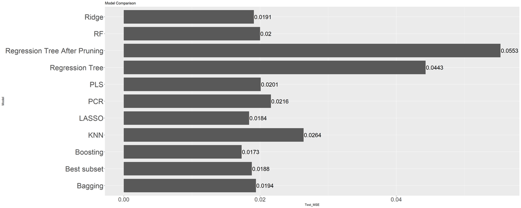